# Getting started with network methods for estimating demographic quantities

RSF migration workshop tutorial

```r
library(tidyverse)
library(networkreporting)
library(surveybootstrap)
library(ggrepel)

theme_set(theme_minimal()) # theme for plots
```

## Prelminary: sign up for the group!

I created an email list that you can access [here](https://groups.google.com/d/forum/networkreporting). If you are interested in network reporting, please sign up!

## Introduction

In this tutorial, we’ll go through a typical analysis that uses survey data about respondents’ reported network connections. These data are a little different from the network reports in my talk about estimating internet adoption; in this case, we’ll look at a dataset that was produced by asking respondents to a household survey questions like “How many nurses have you shared a meal with in the past year?” This type of data has been called *aggregate relational data*, and it’s often collected with the goal of using the network scale-up method.

In order to analyze these data, we’ll use the **networkreporting** package. **networkreporting** has various tools that are using for analyzing network reporting data, including aggregate relational data that have been collected using the network scale-up method.

This introduction will assume that you already have the **networkreporting** package installed. If you don’t, please refer to the instructions you were sent before the tutorial.

## Review of the network scale-up method

For the purposes of this tutorial, we’ll assume that you have conducted a survey using network scale-up questions in order to estimate the size of a hidden population. Analytically, using the scale-up estimator involves two steps:

- step 1: estimating the size of the survey respondents’ personal networks (their *degrees*)
- step 2: estimating the size of the hidden population by combining the estimated network sizes (from step 1) with the number of connections to the hidden population

We’ll quickly review each of these steps, and then we’ll show how to use the package to carry the estimation out.

### Step 1: estimating network sizes

Here, we will use the *known population* estimator for respondents’ degrees (Killworth et al., 1998; Feehan and Salganik, 2016). In order to estimate the degree of the $i$ th survey respondent, we use the

$$\begin{align}
\label{eqn:kpdegree}
\hat{d_i} = \sum_{j=1}^{K} y_{ij} \times
\frac{N}{\sum_{j=1}^{K} N_j},
\end{align}$$

where $N$ is the total size of the population, $N_j$ is the size of the $j$ th population of known size, and $y_{ij}$ is the number of connections that survey respondent $i$ reports between herself and members of the $j$ th population of known size.

### Step 2: estimating hidden population sizes

where $N_h$ is the size of the population of interest (which we want to estimate), $s$ is the set of respondents in our sample, and $\hat{d_i}$ is the estimate of the size of respondent $i$’s degree, obtained using the known population method. In this tutorial, we’ll use clients of sex workers as an example hidden population.

## Preparing data

We will assume that you start with two datasets: the first is a survey containing information collected from respondents about their personal networks; the second is information about the sizes of several populations.

The example data for this tutorial are provided with the `networkreporting` package, and can be loaded by typing

```r
## column names for connections to hidden population numbers
hidden.q <- c("sex.workers", "msm", "idu", "clients")

## column names for connections to groups of known size
hm.q <- c("widower", "nurse.or.doctor", "male.community.health", "teacher",
          "woman.smoke", "priest", "civil.servant", "woman.gave.birth",
          "muslim", "incarcerated", "judge", "man.divorced", "treatedfortb",
          "nsengimana", "murekatete", "twahirwa", "mukandekezi", "nsabimana",
          "mukamana", "ndayambaje", "nyiraneza", "bizimana", "nyirahabimana",
          "ndagijimana", "mukandayisenga", "died")

## size of the entire population
tot.pop.size <- 10718378

## size of the frame population
tot.frame.size <- 5993742
```

The example data include two datasets: one has all of the responses from a network scale-up survey, and the other has the known population sizes for use with the known population estimator.

### Preparing the known population data

The demo known population data are in `example.knownpop.dat`:

```r
example.knownpop.dat
```

| known.popn | size |
| --- | --- |
| widower | 36147 |
| nurse.or.doctor | 7807 |
| male.community.health | 22000 |
| teacher | 47745 |
| woman.smoke | 119438 |
| priest | 1004 |
| woman.gave.birth | 256164 |
| muslim | 195449 |
| incarcerated | 68000 |
| man.divorced | 50698 |

[output cut: 12 more lines]

`example.knownpop.dat` is very simple: one column has a name for each known population, and the other has its toal size. We expect that users will typically start with a small dataset like this one. But, when using the `networkreporting` package, it is more useful to have a vector whose entries are known population sizes and whose names are the known population names. The `df.to.kpvec` function makes it easy for us to create it:

```r
kp.vec <- df.to.kpvec(example.knownpop.dat, kp.var="known.popn", kp.value="size")

kp.vec
```

```
              widower       nurse.or.doctor male.community.health
                36147                  7807                 22000
              teacher           woman.smoke                priest
                47745                119438                  1004
     woman.gave.birth                muslim          incarcerated
               256164                195449                 68000
         man.divorced            nsengimana            murekatete
                50698                 32528                 30531
             twahirwa           mukandekezi             nsabimana
                10420                 10520                 48560
             mukamana            ndayambaje             nyiraneza
                51449                 22724                 21705
             bizimana         nyirahabimana           ndagijimana
                38497                 42727                 37375
       mukandayisenga
                35055
```

Finally, we also need to know the total size of the population we are making estimates about. In this case, let’s assume that we’re working in a country of about 10 million people; the population size is in the variable `tot.pop.size`:

```r
tot.pop.size
```

```
[1] 10718378
```

### Preparing the survey data

Now let’s take a look at the demo survey dataset, which is called `example.survey`:

```r
glimpse(example.survey)
```

```
Observations: 2,406
Variables: 36
$ id                    <chr> "1.1.1", "1.1.2", "1.1.3", "1.1.4", "1.1...
$ cluster               <dbl> 1, 1, 1, 1, 1, 1, 1, 1, 1, 1, 1, 1, 1, 1...
$ region                <fctr> Kigali City, Kigali City, Kigali City, ...
$ indweight             <dbl> 0.330602, 0.330602, 0.330602, 0.330602, ...
$ sex                   <fctr> Male, Male, Male, Male, Male, Male, Mal...
$ age.cat               <fctr> [25,35), [25,35), [25,35), [25,35), [25...
$ widower               <dbl> 3, 0, 2, 0, 0, 7, 0, 0, 0, 0, 4, 0, 0, 0...
$ nurse.or.doctor       <dbl> 2, 2, 8, 1, 0, 4, 1, 0, 0, 2, 0, 0, 0, 0...
$ male.community.health <dbl> 1, 1, 0, 0, 0, 0, 0, 0, 0, 0, 0, 3, 0, 1...
$ teacher               <dbl> 5, 5, 3, 0, 0, 8, 0, 0, 0, 0, 0, 1, 0, 0...
$ woman.smoke           <dbl> 1, 0, 0, 0, 0, 2, 0, 0, 0, 2, 10, 0, 0, ...
$ priest                <dbl> 0, 0, 0, 0, 0, 0, 0, 0, 0, 0, 0, 0, 0, 0...
$ civil.servant         <dbl> 5, 5, 50, 5, 5, 6, 6, 0, 0, 0, 3, 0, 0, ...
```

[output cut: 23 more lines]

The columns fall into a few categories:

- an id variable for each respondent: `id`
- information related to the sampling design of the survey: `cluster`, `region`, and `indweight`.
- demographic characteristics of the respondents: `sex` and `age.cat`
- responses to questiona bout populations whose total size is known: `widower`, …, `mukandayisenga`
- questions about hidden populations: `died`, …, `clients`

This is the general form that your survey dataset should have.

The first thing we’re going to do is to rescale the weights. They were delivered to us as relative weights, but we’ll want them to add up to the size of the frame population.

```r
example.survey <- example.survey %>% mutate(indweight = tot.frame.size * indweight / sum(indweight))
```

#### Topcoding

Many network scale-up studies have topcoded the responses to the aggregate relational data questions (this is also called [Winsorization](https://en.wikipedia.org/wiki/Winsorizing)). This means that researchers considered any responses above a certain value, called the topcode, to be implausible. Before proceeding with the analysis, researchers substitute the maximum plausible value in for the implausible ones. For example, in many studies, researchers replaced responses with the value 31 or higher with the value 30 before conducting their analysis (see Zheng, Salganik, and Gelman 2006).

We won’t discuss whether or not this is advisable here, but this is currently a common practice in scale-up studies. If you wish to follow it, you can use the `topcode.data` function. For example, let’s topcode the responses to the questions about populations of known size to the value 30. First, we’ll examine the distribution of the responses before topcoding:

```r
## make a vector with the list of known population names from
## our dataset of known population totals
known.popn.vars <- paste(example.knownpop.dat$known.popn)

## before topcoding: max. response for several popns is > 30
summary(example.survey[,known.popn.vars])
```

```
    widower        nurse.or.doctor   male.community.health
 Min.   : 0.0000   Min.   : 0.0000   Min.   : 0.000
 1st Qu.: 0.0000   1st Qu.: 0.0000   1st Qu.: 0.000
 Median : 0.0000   Median : 0.0000   Median : 0.000
 Mean   : 0.6101   Mean   : 0.5112   Mean   : 0.724
 3rd Qu.: 0.0000   3rd Qu.: 0.0000   3rd Qu.: 1.000
 Max.   :95.0000   Max.   :40.0000   Max.   :95.000

    teacher        woman.smoke         priest        woman.gave.birth
 Min.   : 0.000   Min.   : 0.000   Min.   : 0.0000   Min.   : 0.000
 1st Qu.: 0.000   1st Qu.: 0.000   1st Qu.: 0.0000   1st Qu.: 0.000
 Median : 0.000   Median : 0.000   Median : 0.0000   Median : 1.000
 Mean   : 1.356   Mean   : 1.022   Mean   : 0.1484   Mean   : 1.885
 3rd Qu.: 1.000   3rd Qu.: 1.000   3rd Qu.: 0.0000   3rd Qu.: 3.000
 Max.   :95.000   Max.   :95.000   Max.   :25.0000   Max.   :30.000

     muslim        incarcerated      man.divorced       nsengimana
 Min.   : 0.000   Min.   : 0.0000   Min.   : 0.0000   Min.   :0.0000
 1st Qu.: 0.000   1st Qu.: 0.0000   1st Qu.: 0.0000   1st Qu.:0.0000
 Median : 0.000   Median : 0.0000   Median : 0.0000   Median :0.0000
 Mean   : 2.094   Mean   : 0.4348   Mean   : 0.3367   Mean   :0.3603
 3rd Qu.: 1.000   3rd Qu.: 0.0000   3rd Qu.: 0.0000   3rd Qu.:0.0000
 Max.   :95.000   Max.   :95.0000   Max.   :20.0000   Max.   :8.0000
 NA's   :1
   murekatete         twahirwa        mukandekezi      nsabimana
 Min.   : 0.0000   Min.   : 0.0000   Min.   :0.000   Min.   : 0.0000
 1st Qu.: 0.0000   1st Qu.: 0.0000   1st Qu.:0.000   1st Qu.: 0.0000
 Median : 0.0000   Median : 0.0000   Median :0.000   Median : 0.0000
 Mean   : 0.3425   Mean   : 0.2394   Mean   :0.165   Mean   : 0.4705
 3rd Qu.: 1.0000   3rd Qu.: 0.0000   3rd Qu.:0.000   3rd Qu.: 1.0000
 Max.   :12.0000   Max.   :10.0000   Max.   :7.000   Max.   :20.0000

    mukamana         ndayambaje        nyiraneza          bizimana
 Min.   : 0.0000   Min.   : 0.0000   Min.   : 0.0000   Min.   : 0.0000
 1st Qu.: 0.0000   1st Qu.: 0.0000   1st Qu.: 0.0000   1st Qu.: 0.0000
 Median : 0.0000   Median : 0.0000   Median : 0.0000   Median : 0.0000
 Mean   : 0.4144   Mean   : 0.3296   Mean   : 0.2685   Mean   : 0.4331
 3rd Qu.: 1.0000   3rd Qu.: 0.0000   3rd Qu.: 0.0000   3rd Qu.: 1.0000
 Max.   :15.0000   Max.   :30.0000   Max.   :10.0000   Max.   :12.0000

 nyirahabimana     ndagijimana      mukandayisenga
 Min.   : 0.000   Min.   : 0.0000   Min.   : 0.0000
 1st Qu.: 0.000   1st Qu.: 0.0000   1st Qu.: 0.0000
 Median : 0.000   Median : 0.0000   Median : 0.0000
 Mean   : 0.261   Mean   : 0.3279   Mean   : 0.2577
 3rd Qu.: 0.000   3rd Qu.: 0.0000   3rd Qu.: 0.0000
 Max.   :17.000   Max.   :10.0000   Max.   :20.0000
```

It’s usually more helpful to look at plots:

```r
hm.raw <- map(known.popn.vars,
               function(kp) {
                 plotdat <- example.survey %>% select(thiscol=kp)
                 #thisname <- hm.labels[kp]
                 thisname <- kp

                 p <- ggplot(plotdat) +
                   geom_histogram(aes(x=thiscol), binwidth=1) +
                   xlab(thisname) +
                   theme_minimal()

                 return(p)
               })
hm.raw <- setNames(hm.raw, known.popn.vars)
```

Look at a couple of examples (feel free to explore more):

```r
names(hm.raw)
```

```
 [1] "widower"               "nurse.or.doctor"
 [3] "male.community.health" "teacher"
 [5] "woman.smoke"           "priest"
 [7] "woman.gave.birth"      "muslim"
 [9] "incarcerated"          "man.divorced"
[11] "nsengimana"            "murekatete"
[13] "twahirwa"              "mukandekezi"
[15] "nsabimana"             "mukamana"
[17] "ndayambaje"            "nyiraneza"
[19] "bizimana"              "nyirahabimana"
[21] "ndagijimana"           "mukandayisenga"
```

```
widower

nurse.or.doctor

male.community.health

teacher

woman.smoke

priest

woman.gave.birth

muslim

incarcerated

man.divorced

nsengimana

murekatete

twahirwa

mukandekezi

nsabimana

mukamana

ndayambaje

nyiraneza

bizimana

nyirahabimana

ndagijimana

mukandayisenga
```

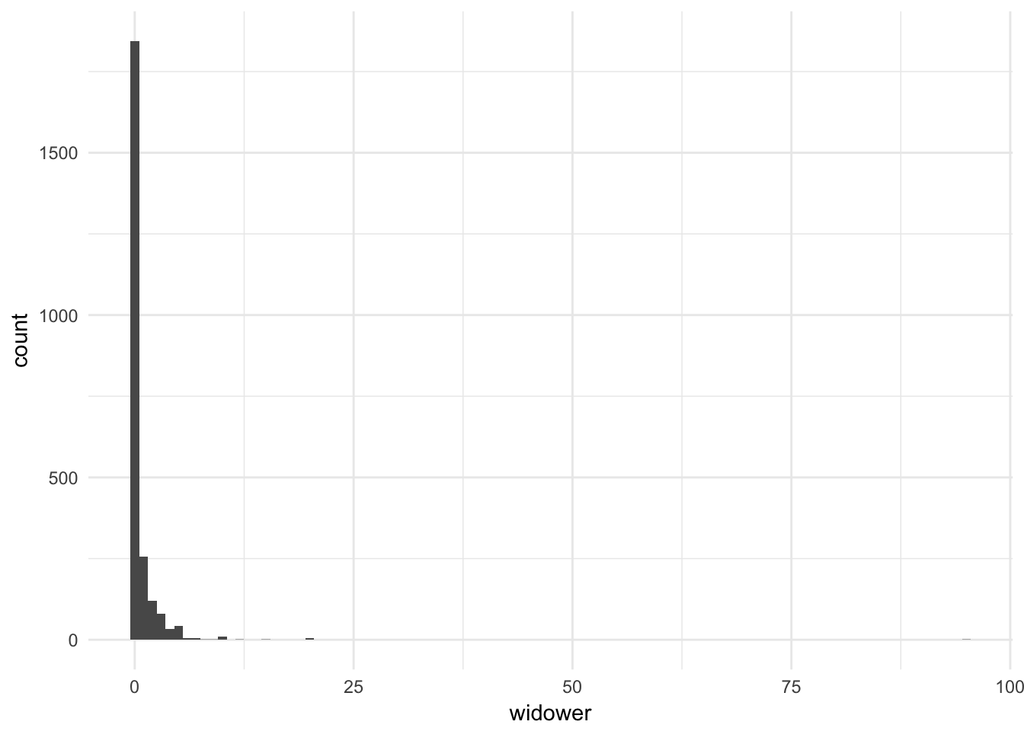

```r
hm.raw[[1]]
```

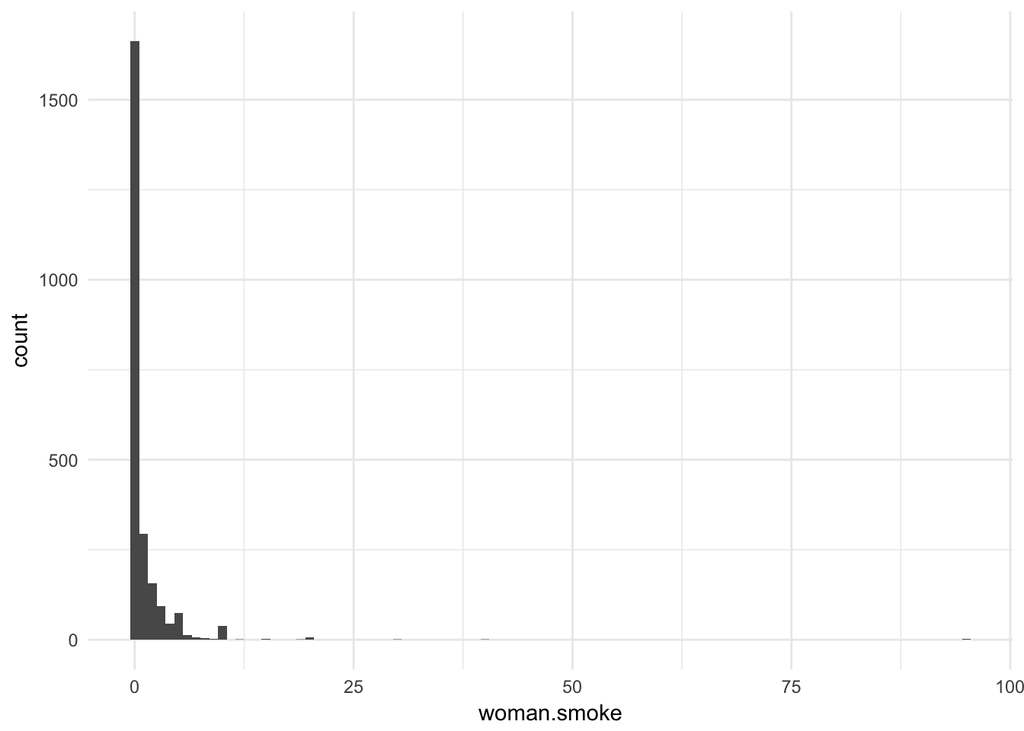

```r
hm.raw[['woman.smoke']]
```

Several populations, including `widower`, `male.community.health`, `teacher`, `woman.smoke`, `muslim`, and `incarcerated` have maximum values that are very high. (It turns out that 95 is the highest value that could be recorded during the interviews; if respondents said that they were connected to more than 95 people in the group, the interviewers wrote 95 down.)

Now we use the `topcode.data` function to topcode all of the responses at 30:

```r
example.survey <- topcode.data(example.survey,
                               vars=known.popn.vars,
                               max=30)

## after topcoding: max. response for all popns is 30
summary(example.survey[,known.popn.vars])
```

```
    widower        nurse.or.doctor   male.community.health
 Min.   : 0.0000   Min.   : 0.0000   Min.   : 0.000
 1st Qu.: 0.0000   1st Qu.: 0.0000   1st Qu.: 0.000
 Median : 0.0000   Median : 0.0000   Median : 0.000
 Mean   : 0.5831   Mean   : 0.5062   Mean   : 0.653
 3rd Qu.: 0.0000   3rd Qu.: 0.0000   3rd Qu.: 1.000
 Max.   :30.0000   Max.   :30.0000   Max.   :30.000

    teacher        woman.smoke          priest        woman.gave.birth
 Min.   : 0.000   Min.   : 0.0000   Min.   : 0.0000   Min.   : 0.000
 1st Qu.: 0.000   1st Qu.: 0.0000   1st Qu.: 0.0000   1st Qu.: 0.000
 Median : 0.000   Median : 0.0000   Median : 0.0000   Median : 1.000
 Mean   : 1.216   Mean   : 0.9638   Mean   : 0.1484   Mean   : 1.885
 3rd Qu.: 1.000   3rd Qu.: 1.0000   3rd Qu.: 0.0000   3rd Qu.: 3.000
 Max.   :30.000   Max.   :30.0000   Max.   :25.0000   Max.   :30.000

     muslim        incarcerated      man.divorced       nsengimana
 Min.   : 0.000   Min.   : 0.0000   Min.   : 0.0000   Min.   :0.0000
 1st Qu.: 0.000   1st Qu.: 0.0000   1st Qu.: 0.0000   1st Qu.:0.0000
 Median : 0.000   Median : 0.0000   Median : 0.0000   Median :0.0000
 Mean   : 1.468   Mean   : 0.3807   Mean   : 0.3367   Mean   :0.3603
 3rd Qu.: 1.000   3rd Qu.: 0.0000   3rd Qu.: 0.0000   3rd Qu.:0.0000
 Max.   :30.000   Max.   :30.0000   Max.   :20.0000   Max.   :8.0000
 NA's   :1
   murekatete         twahirwa        mukandekezi      nsabimana
 Min.   : 0.0000   Min.   : 0.0000   Min.   :0.000   Min.   : 0.0000
 1st Qu.: 0.0000   1st Qu.: 0.0000   1st Qu.:0.000   1st Qu.: 0.0000
 Median : 0.0000   Median : 0.0000   Median :0.000   Median : 0.0000
 Mean   : 0.3425   Mean   : 0.2394   Mean   :0.165   Mean   : 0.4705
 3rd Qu.: 1.0000   3rd Qu.: 0.0000   3rd Qu.:0.000   3rd Qu.: 1.0000
 Max.   :12.0000   Max.   :10.0000   Max.   :7.000   Max.   :20.0000

    mukamana         ndayambaje        nyiraneza          bizimana
 Min.   : 0.0000   Min.   : 0.0000   Min.   : 0.0000   Min.   : 0.0000
 1st Qu.: 0.0000   1st Qu.: 0.0000   1st Qu.: 0.0000   1st Qu.: 0.0000
 Median : 0.0000   Median : 0.0000   Median : 0.0000   Median : 0.0000
 Mean   : 0.4144   Mean   : 0.3296   Mean   : 0.2685   Mean   : 0.4331
 3rd Qu.: 1.0000   3rd Qu.: 0.0000   3rd Qu.: 0.0000   3rd Qu.: 1.0000
 Max.   :15.0000   Max.   :30.0000   Max.   :10.0000   Max.   :12.0000

 nyirahabimana     ndagijimana      mukandayisenga
 Min.   : 0.000   Min.   : 0.0000   Min.   : 0.0000
 1st Qu.: 0.000   1st Qu.: 0.0000   1st Qu.: 0.0000
 Median : 0.000   Median : 0.0000   Median : 0.0000
 Mean   : 0.261   Mean   : 0.3279   Mean   : 0.2577
 3rd Qu.: 0.000   3rd Qu.: 0.0000   3rd Qu.: 0.0000
 Max.   :17.000   Max.   :10.0000   Max.   :20.0000
```

If you look at the help page for `topcode.data`, you’ll see that it can also handle situations where the variables can take on special codes for missing values, refusals, and so forth.

We can redo our plots to check the topcoded distributions:

```r
# this vector maps variable names to descriptive labels
hm.topcoded <- map(known.popn.vars,
               function(kp) {
                 plotdat <- example.survey %>% select(thiscol=kp)
                 thisname <- kp


                 p <- ggplot(plotdat) +
                   geom_histogram(aes(x=thiscol), binwidth=1) +
                   xlab(thisname) +
                   theme_minimal()

                 return(p)
               })
hm.topcoded <- setNames(hm.topcoded, known.popn.vars)
```

And let’s check that this all worked…

```r
names(hm.topcoded)
```

```
 [1] "widower"               "nurse.or.doctor"
 [3] "male.community.health" "teacher"
 [5] "woman.smoke"           "priest"
 [7] "woman.gave.birth"      "muslim"
 [9] "incarcerated"          "man.divorced"
[11] "nsengimana"            "murekatete"
[13] "twahirwa"              "mukandekezi"
[15] "nsabimana"             "mukamana"
[17] "ndayambaje"            "nyiraneza"
[19] "bizimana"              "nyirahabimana"
[21] "ndagijimana"           "mukandayisenga"
```

```
widower

nurse.or.doctor

male.community.health

teacher

woman.smoke

priest

woman.gave.birth

muslim

incarcerated

man.divorced

nsengimana

murekatete

twahirwa

mukandekezi

nsabimana

mukamana

ndayambaje

nyiraneza

bizimana

nyirahabimana

ndagijimana

mukandayisenga
```

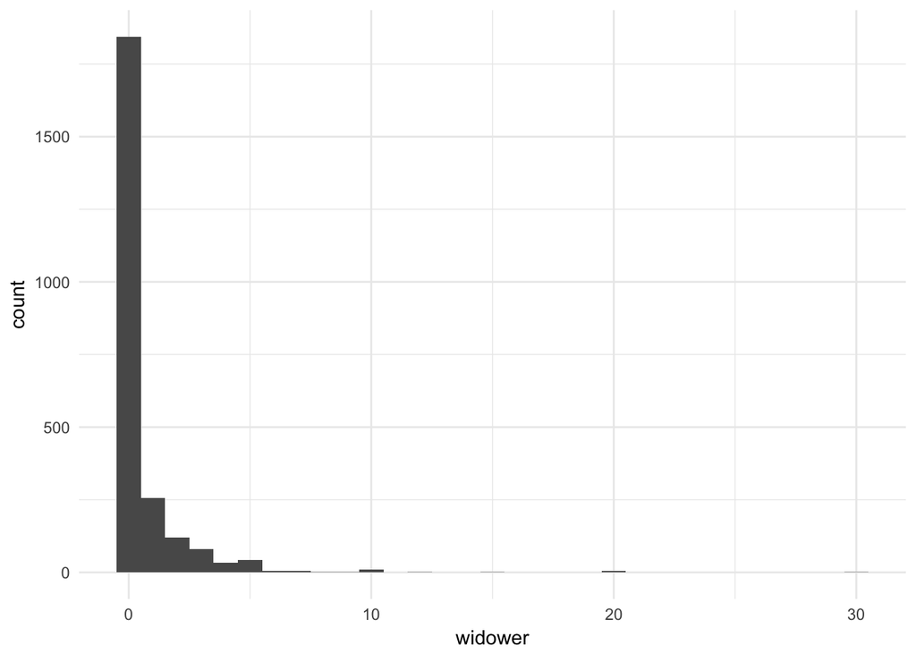

```r
hm.topcoded[[1]]
```

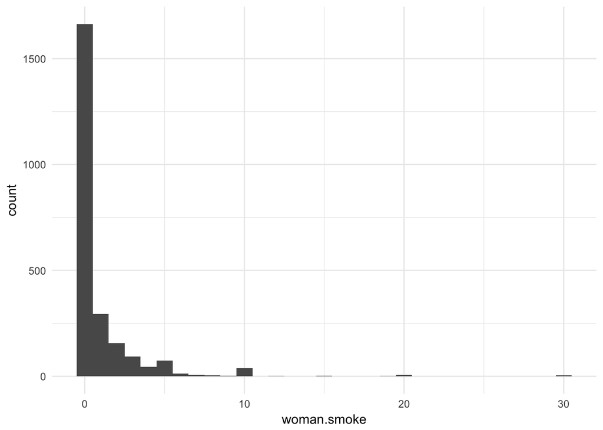

```r
hm.topcoded[['woman.smoke']]
```

## Avg number reported vs known popn size

After examining the distribution of responses to the aggregate relational survey items (e.g., the ‘how many X do you know?’ questions), the next step is typically to examine the relationship between the average number of reported connections to each group of known size and the size of each group. Although we don’t necessarily expect these to be perfectly related, we expect there to be a strong positive relationship between these two quantities: in other words, we expect people will report, on average, more connections to groups that are bigger. We’ll take a look at this next, by creating a plot:

```r
# calculate the (weighted) average number known for each group
ank.kp <- example.survey %>%
  select(c(known.popn.vars, 'indweight')) %>%
  gather(kp, num_known, -indweight) %>%
  group_by(kp) %>%
  dplyr::summarize(avg_num_known = weighted.mean(num_known, weight=indweight, na.rm=TRUE))

ank.kp
```

| kp | avg_num_known |
| --- | --- |
| bizimana | 0.4330840 |
| incarcerated | 0.3807149 |
| male.community.health | 0.6529510 |
| man.divorced | 0.3366584 |
| mukamana | 0.4143807 |
| mukandayisenga | 0.2576891 |
| mukandekezi | 0.1650042 |
| murekatete | 0.3424771 |
| muslim | 1.4677755 |
| ndagijimana | 0.3279302 |

[output cut: 12 more lines]

```r
# make a dataframe with the known population values, so we can
# join it into the average reported connections
kp.df <- data_frame(kp = names(kp.vec),
                    tot = kp.vec)

kp.df
```

| kp | tot |
| --- | --- |
| widower | 36147 |
| nurse.or.doctor | 7807 |
| male.community.health | 22000 |
| teacher | 47745 |
| woman.smoke | 119438 |
| priest | 1004 |
| woman.gave.birth | 256164 |
| muslim | 195449 |
| incarcerated | 68000 |
| man.divorced | 50698 |

[output cut: 12 more lines]

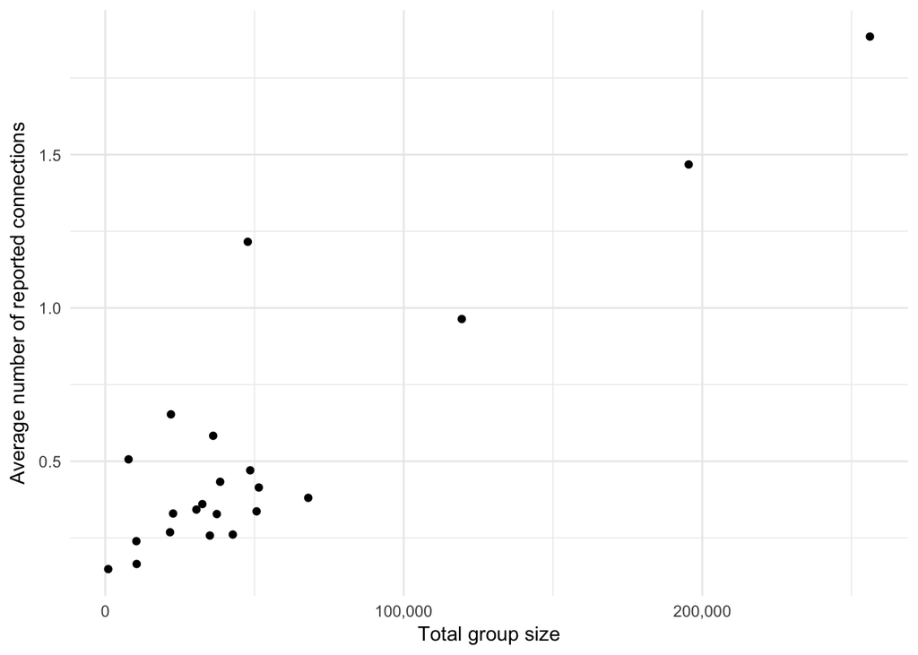

```r
# merge the average number of reported connections and the
# actual size of each group into a single dataset
compare.kp <- ank.kp %>%
  left_join(kp.df)
# and, finally, plot that relationship
ank.kp.plot <- ggplot(compare.kp) +
  geom_point(aes(x=tot, y=avg_num_known)) +
  xlab("Total group size") +
  ylab("Average number of reported connections") +
  scale_x_continuous(label=scales::comma) +
  theme_minimal()

ank.kp.plot
```

If you want a plot that shows the identity of each point, you can use the `ggrepel` package:

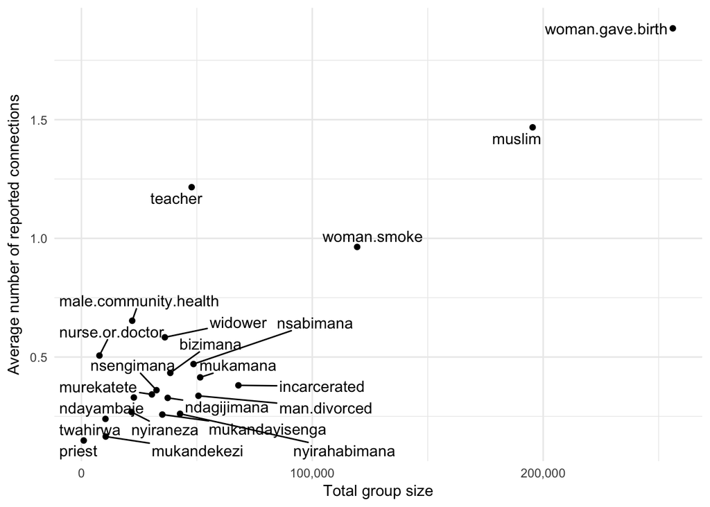

```r
ank.kp.plot.labs <- ggplot(compare.kp) +
  geom_point(aes(x=tot, y=avg_num_known)) +
  geom_text_repel(aes(x=tot, y=avg_num_known, label=kp)) +
  xlab("Total group size") +
  ylab("Average number of reported connections") +
  scale_x_continuous(label=scales::comma) +
  theme_minimal()

ank.kp.plot.labs
```

## Estimating network sizes

```r
d.hat <- kp.individual.estimator(resp.data=example.survey,
                                  known.populations=known.popn.vars,
                                  total.kp.size=sum(kp.vec),
                                  alter.popn.size=tot.pop.size)$dbar.Fcell.F
```

```
NOTE: Ignoring any rows with missingness on any of the report variables.
```

```r
summary(d.hat)
```

```
   Min. 1st Qu.  Median    Mean 3rd Qu.    Max.
   0.00   27.10   63.23  108.50  135.50 2042.00
```

We can examine the results with a histogram

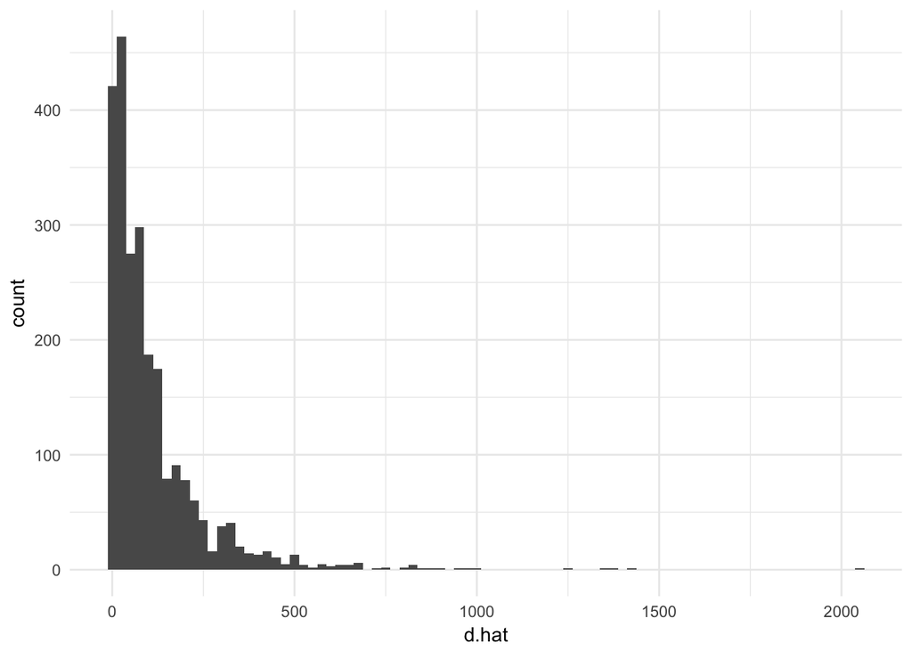

```r
qplot(d.hat, binwidth=25)
```

Now let’s append the degree estimates to the survey reports dataframe:

```r
example.survey$d.hat <- d.hat
```

## Estimating average degree

We can also directly estimate the average degree using the kp estimator (this is slightly different from estimating the degree of each individual respondent):

```r
d.bar.hat<- kp.estimator(resp.data=example.survey,
                         known.populations=known.popn.vars,
                         total.kp.size=sum(kp.vec),
                         weights="indweight",
                         alter.popn.size=tot.pop.size)
```

```
NOTE: Ignoring any rows with missingness on any of the report variables.
```

```r
d.bar.hat
```

| sum.y.kp | wgt.total.y.kp | num.obs.y.kp | sum.y.kp.over.kptot | dbar.Fcell.F |
| --- | --- | --- | --- | --- |
| 71723780 | 5993742 | 2406 | 60.44769 | 108.0963 |

## Estimating hidden population size

Now that we have estimated degrees, we can use them to produce estimates of the size of the hidden population. Here, we’ll take the example of clients of female sex workers, `clients`

```r
clients.est <- nsum.estimator(survey.data=example.survey,
                              d.hat.vals=d.hat,
                              total.popn.size=tot.pop.size,
                              y.vals="clients",
                              missing="complete.obs")
```

Note that we had to specify that we should use only rows in our dataset with no missing values through the `missing = "complete.obs"` option, and also that we had to pass in the total population size using the `total.popn.size` option. The resulting estimate is

```r
clients.est
```

```
$estimate
[1] 47798.44

$tot.connections
[1] 1164

$sum.d.hat
[1] 261016.7
```

This returns the estimate, and also the numerator and denominator used to compute it.

## Variance estimation

In order to estimate the sampling uncertainty of our estimated totals, we can use the rescaled bootstrap technique [see Rao and Wu (1988) for the original derivation of the rescaled bootstrap, and Feehan and Salganik 2016 for more about the rescaled boostrap and how it can be applied to the network scale-up method].

In order to use the rescaled boostrap, you need to be able to specify the sampling design of your study. In particular, you need to be able to describe the stratifcation (if any) and the primary sampling units used in the study.

```r
clients.est <- bootstrap.estimates(## this describes the sampling design of the
                                   ## survey; here, the PSUs are given by the
                                   ## variable cluster, and the strata are given
                                   ## by the variable region
                                   survey.design = ~ cluster + strata(region),
                                   ## the number of bootstrap resamples to obtain
                                   num.reps=1000,
                                   ## this is the name of the function
                                   ## we want to use to produce an estimate
                                   ## from each bootstrapped dataset
                                   estimator.fn="nsum.estimator",
                                   ## these are the sampling weights
                                   weights="indweight",
                                   ## this is the name of the type of bootstrap
                                   ## we wish to use
                                   bootstrap.fn="rescaled.bootstrap.sample",
                                   ## our dataset
                                   survey.data=example.survey,
                                   ## other parameters we need to pass
                                   ## to the nsum.estimator function
                                   d.hat.vals=d.hat,
                                   total.popn.size=tot.pop.size,
                                   y.vals="clients",
                                   missing="complete.obs")
```

By default, `bootstrap.estimates` produces a list with `num.reps` entries; each entry is the result of calling the estimator function on one bootstrap resample.

Next, you can write a bit of code that will help us put all of these results together, for plotting and summarizing

```r
## combine the estimates together in one data frame
## (bootstrap.estimates gives us a list)
all.clients.estimates <- ldply(clients.est,
                               function(x) { data.frame(estimate=x$estimate) })
```

Finally, we can examine the summarized results with a histogram or with `summarize`.

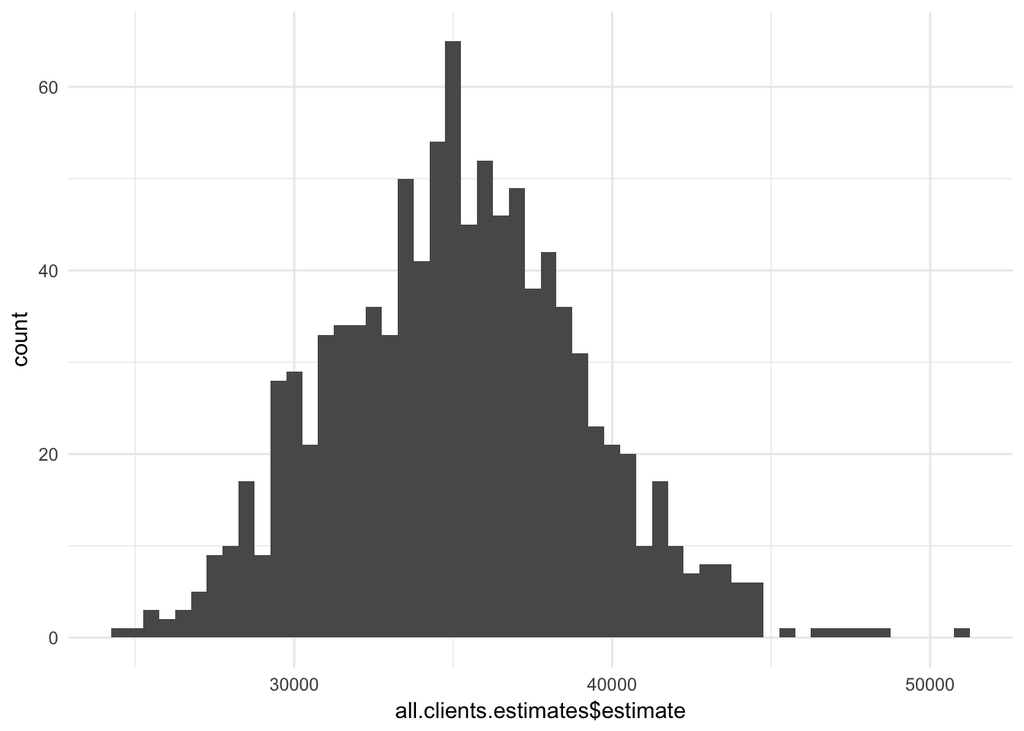

```r
## look at a histogram of the results
qplot(all.clients.estimates$estimate, binwidth=500)
```

```r
## summarize the results
summary(all.clients.estimates$estimate)
```

```
   Min. 1st Qu.  Median    Mean 3rd Qu.    Max.
  24320   32430   35100   35180   37810   50870
```

To produce 95% intervals using the percentile method you can use R’s `quantile` function:

```r
quantile(all.clients.estimates$estimate, probs=c(0.025, 0.975))
```

```
    2.5%    97.5%
27923.85 43366.43
```

## Internal consistency checks

If you want to conduct internal consistency checks (see e.g. [Feehan et al., 2016, Fig 3](https://doi.org/10.1093/aje/kwv287)), you can use the `nsum.internal.consistency` function. We specify that we wish to use only complete observations (ie, we will remove rows that have any missing values from our calculations).

[You should see several copies of a message warning you about ignoring missingness; in our case, there is only one row with missingness, so we will disregard the warning.]

```r
ic.result <- nsum.internal.consistency(survey.data=example.survey,
                                       known.popns=kp.vec,
                                       missing="complete.obs",
                                       killworth.se=FALSE,
                                       weights="indweight",
                                       total.popn.size=tot.pop.size,
                                       kp.method=TRUE,
                                       return.plot=TRUE)
```

[output not shown]

Now `ic.result` is a list that has a summary of the results in the entry `results`

```r
ic.result$results
```

| name | nsum.holdout.est | known.size | d.hat.sum | killworth.se | killworth.se.wgtdenom | err | abserr | sqerr | relerr |
| --- | --- | --- | --- | --- | --- | --- | --- | --- | --- |
| widower | 111170.42 | 36147 | 143237.6 | NA | NA | 75023.418 | 75023.418 | 5628513226 | 2.07550883 |
| nurse.or.doctor | 77484.73 | 7807 | 140734.5 | NA | NA | 69677.729 | 69677.729 | 4854985886 | 8.92503251 |
| male.community.health | 137989.53 | 22000 | 140632.9 | NA | NA | 115989.527 | 115989.527 | 13453570448 | 5.27225124 |
| teacher | 213119.79 | 47745 | 136685.8 | NA | NA | 165374.791 | 165374.791 | 27348821469 | 3.46370910 |
| woman.smoke | 177985.70 | 119438 | 149272.7 | NA | NA | 58547.701 | 58547.701 | 3427833318 | 0.49019325 |
| priest | 19070.88 | 1004 | 144279.9 | NA | NA | 18066.883 | 18066.883 | 326412256 | 17.99490324 |
| woman.gave.birth | 331692.04 | 256164 | 156933.4 | NA | NA | 75528.038 | 75528.038 | 5704484481 | 0.29484251 |
| muslim | 168131.43 | 195449 | 153397.4 | NA | NA | -27317.575 | 27317.575 | 746249897 | 0.13976830 |
| incarcerated | 66447.87 | 68000 | 149926.2 | NA | NA | -1552.134 | 1552.134 | 2409120 | 0.02282550 |
| man.divorced | 53139.17 | 50698 | 148201.8 | NA | NA | 2441.166 | 2441.166 | 5959291 | 0.04815113 |

[output cut: 12 more lines]

Let’s make a plot to visualize these results more easily:

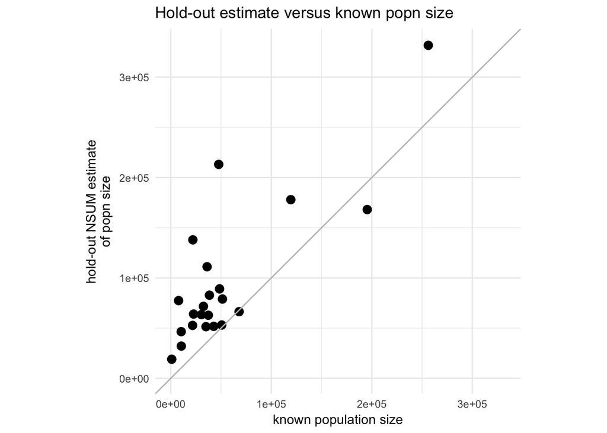

```r
toplot <- ic.result$results
custom.ic.plot <- ggplot(toplot) +
               geom_point(aes(x=known.size, y=nsum.holdout.est),
                         size=3) +
               coord_equal(ratio=1) +
               xlim(with(toplot,
                         range(known.size,nsum.holdout.est,na.rm=TRUE))) +
               ylim(with(toplot,
                         range(known.size,nsum.holdout.est,na.rm=TRUE))) +
               geom_abline(intercept=0, slope=1, color='grey') +
               ggtitle(paste("Hold-out estimate versus known popn size")) +
               xlab("known population size") +
               ylab("hold-out NSUM estimate\nof popn size")
custom.ic.plot
```

## Sensitivity analysis

Finally, you may not believe that all of the conditions required by the scale-up estimator hold in your study. Thus, it might be useful to conduct a sensitivity analysis to get a sense for how much violating the various conditions would impact your estimates.

The papers have a full derivation of the sensitivity framework for network scale-up; to illustrate this approach, you can use the following Shiny widget to conduct a partial sensitivity analysis yourself:

```r
shiny::runGitHub( "gnsum-sensitivity-widget", "dfeehan")
```

## Sign up for the group!

I created an email list that you can access [here](https://groups.google.com/d/forum/networkreporting). If you are interested in network reporting, please sign up!

Also, if you use this package, please cite us. You can get a citation in R by typing:

```r
citation('networkreporting')
```

```
Dennis M. Feehan and Matthew J. Salganik (2014). _The
networkreporting package_. <URL:
http://cran.r-project.org/package=networkreporting>.

A BibTeX entry for LaTeX users is

  @Manual{,
    title = {The networkreporting package},
    year = {2014},
    url = {http://cran.r-project.org/package=networkreporting},
    author = {{Dennis M. Feehan} and {Matthew J. Salganik}},
  }
```

```r
citation('surveybootstrap')
```

```
It is recommended to use 'given' instead of 'middle'.
It is recommended to use 'given' instead of 'middle'.
```

```
  Dennis M. Feehan (2016). surveybootstrap: Tools for the
  Bootstrap with Survey Data. R package version 0.0.1.
  https://CRAN.R-project.org/package=surveybootstrap

A BibTeX entry for LaTeX users is

  @Manual{,
    title = {surveybootstrap: Tools for the Bootstrap with Survey Data},
    author = {Dennis M. Feehan},
    year = {2016},
    note = {R package version 0.0.1},
    url = {https://CRAN.R-project.org/package=surveybootstrap},
  }
```

## Selected references

Here are a few selected references, but there is more relevant literature; please see the papers for more.

- Bernard, H. R., Johnsen, E. C., Killworth, P. D., & Robinson, S. (1989). Estimating the size of an average personal network and of an event subpopulation. In M. Kochen (Ed.), The Small World (pp. 159–175). Norwood, NJ: Ablex Publishing.
- Feehan, D. M. (2015). Network reporting methods (PhD thesis). Princeton University.
- Feehan, D. M., & Salganik, M. J. (2016). Generalizing the Network Scale-Up Method: A New Estimator for the Size of Hidden Populations. Sociological Methodology.
- Feehan, Dennis M., Aline Umubyeyi, Mary Mahy, Wolfgang Hladik, and Matthew J. Salganik. 2016. “Quantity Versus Quality: A Survey Experiment to Improve the Network Scale-up Method.” American Journal of Epidemiology, March
- Feehan, D. M., Mahy, M., & Salganik, M. J. (2017). The network survival method for estimating adult mortality: Evidence from a survey experiment in Rwanda. Demography, 54(4), 1503–1528.
- Maltiel, Rachael, Adrian E. Raftery, Tyler H. McCormick, and Aaron J. Bara . 2015. “Estiating Population Size Using the Network Scale up Method.” Annals of Applied Statistics 9 (3): 1247–77.
- Rao, J. N. K., & Wu, C. F. J. (1988). Resampling inference with complex survey data. Journal of the American Statistical Association, 83(401), 231–241.
- Sirken, M. G. (1970). Household surveys with multiplicity. Journal of the American Statistical Association, 65(329), 257–266.